# Regras de Associação aplicadas a Campo Harmônico

Arthur Cesar Rocha

2018-08-31

## Introdução

### Campo Harmônico

Pode ser definido como um conjunto de acordes/arpejos (conjunto de notas de uma escala) que definem a tonalidade de uma música.

### Objetivo

Avaliar as músicas sertanejas possuem mais **pobreza musical** em relação as músicas de MPB, assumindo aqui **pobreza musical** como a não diversidade no uso de acordes, consequentemente a frequência no uso de campos harmônicos simples (baseados em tríades) ou ainda nos mesmos campos.

Logo a relação assumida aqui é a seguinte:

+Regras | Regras +fortes $\rightarrow$ +Repetições (Acordes) $\rightarrow$ +Pobreza musical

## Dados

Os dados foram obtidos por meio de técnicas de *web scraping*, isto é, “raspando” dados da web. Primeiramente tomou-se os links das 1000 músicas mais acessadas no **Cifraclub** de cada um dos estilos musicais estudados por meio da ferramenta **linkclump**. A partir daí fez-se uma função em R utilizando a linguagem de consulta **Xpath** com os pacotes `Rcurl` e `XML`, para obter as notas de cada uma das músicas. Em seguida transformou-se os dados na forma de matriz binária para aplicação do algorítmo **apriori**.

O código para fazer a extração do conteúdo é dados abaixo:

```r
###Pacotes----------------------------------------------------------
library(RCurl)     #webscraping
library(XML)       #webscraping
library(dplyr)     #manipulação
library(compiler)  #compilador de função
library(arules)    #regras de associação
library(arulesViz) #gráficos de regras
library(ggplot2)   #gráficos
library(plotly)    #gráficos interativos

###Dados------------------------------------------------------------
#Obtidos pelo Linkclump
setwd("C:\\Users\\ASUS\\Desktop\\Uem\\4 ano\\Mineração\\Trab_regras_associacao")

#1000 mais buscadas no cifraclub - sertanejo
sertanejo=read.csv("Sertanejo1000.csv",sep=";",
                   header = T,stringsAsFactors = F)

#1000 mais buscadas no cifraclub - mpb
mpb.db=read.csv("MPB1000.csv",sep=";",header = T,stringsAsFactors = F)

##Funcoes----------------------------------------------------------

extr= function(url){

  content <- getURL(url) #Lê URL
  doc <- htmlParse(content, asText = TRUE, encoding = "utf-8")

  notas=unique(xpathSApply(doc, path = "//pre/b", fun = xmlValue)) #Busca acordes

  return(notas)
}
extrator = cmpfun(extr)  ##Compila funcao para mais eficiencia


##Manipulação de dados ------------------------------------------

#Extraindo acordes dos links
info1=sertanejo %>%
  select(Link) %>%
  filter(Link!="") %>% apply(MARGIN =  1,extrator) #preciso retirar espaços em branco

info2=mpb.db %>%
  select(Link) %>%
  filter(Link!="") %>% apply(MARGIN =  1,extrator)

## Pegando um vetor com todos os acordes (1 para cada estilo)
a=info1 %>% unlist()
b=info2 %>% unlist()

##Mapeando todos os tipos de acorde
niveis.sert= a %>% factor() %>% levels()
niveis.mpb= b %>% factor() %>% levels()

#########Transformando em matriz binária!!
sert=sapply(info1,
            function(x)factor(x,levels = niveis.sert) %>%table())
sert=t(sert)

mpb=sapply(info2,
            function(x)factor(x,levels = niveis.mpb) %>%table())
mpb=t(mpb)
```

## Resultados

A princípio nota-se na figura abaixo que há uma grande diferença no número de acordes diferentes encontrados em cada um dos estilos, já levando a entender que as músicas sertanejas não se diversificam tanto em seus acordes.

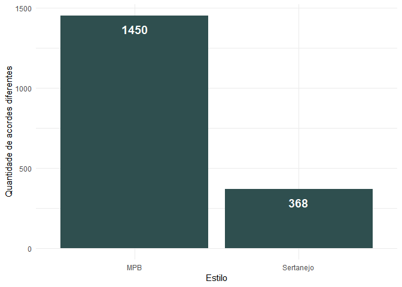

```r
data.frame(Estilo=c("MPB","Sertanejo"),
           Acordes=c(ncol(mpb),
                     ncol(sert))) %>%
  ggplot(aes(x=Estilo,y=Acordes,label=Acordes))+
  geom_bar(stat="identity",fill="darkslategrey")+
  geom_text(vjust=2,col="white",fontface=2,size=5)+
  theme_minimal()+
  ylab("Quantidade de acordes diferentes")
```

Ao se aplicar o algorítmo **apriori** na base de dados referentes as músicas sertanejas, considerando como threshold ($sup_{min}=10\%;conf_{min}=80\%$), obteve-se as seguintes regras:

```r
regras.sert= sert %>%
  apriori(parameter = list(support=0.1,confidence=0.8))

#Removendo regras redundantes e ordenando
regras.sert.o = regras.sert[!is.redundant(regras.sert)]%>%
  sort(by="support")%>%
  inspect
```

```r
knitr::kable(regras.sert.o)
```

|  | lhs |  | rhs | support | confidence | lift | count |
| --- | --- | --- | --- | --- | --- | --- | --- |
| [1] | {C} | => | {G} | 0.373 | 0.8382022 | 1.437740 | 373 |
| [2] | {Em} | => | {G} | 0.275 | 0.8986928 | 1.541497 | 275 |
| [3] | {Am} | => | {C} | 0.269 | 0.8566879 | 1.925141 | 269 |
| [4] | {Am} | => | {G} | 0.266 | 0.8471338 | 1.453060 | 266 |
| [5] | {F} | => | {C} | 0.248 | 0.8522337 | 1.915132 | 248 |
| [6] | {Am,C} | => | {G} | 0.239 | 0.8884758 | 1.523972 | 239 |
| [7] | {Am,G} | => | {C} | 0.239 | 0.8984962 | 2.019093 | 239 |
| [8] | {Bm} | => | {D} | 0.229 | 0.8875969 | 1.796755 | 229 |
| [9] | {D,Em} | => | {G} | 0.215 | 0.9347826 | 1.603401 | 215 |
| [10] | {C,D} | => | {G} | 0.200 | 0.9569378 | 1.641403 | 200 |
| [11] | {F,G} | => | {C} | 0.189 | 0.9174757 | 2.061743 | 189 |
| [12] | {A,G} | => | {D} | 0.185 | 0.9203980 | 1.863154 | 185 |
| [13] | {Dm} | => | {F} | 0.184 | 0.8288288 | 2.848209 | 184 |
| [14] | {Dm} | => | {C} | 0.184 | 0.8288288 | 1.862537 | 184 |
| [15] | {A,Bm} | => | {D} | 0.180 | 0.9523810 | 1.927897 | 180 |
| [16] | {C,Em} | => | {G} | 0.177 | 0.9414894 | 1.614905 | 177 |
| [17] | {F#m} | => | {A} | 0.170 | 0.8333333 | 1.942502 | 170 |
| [18] | {Dm,F} | => | {C} | 0.166 | 0.9021739 | 2.027357 | 166 |
| [19] | {C,Dm} | => | {F} | 0.166 | 0.9021739 | 3.100254 | 166 |
| [20] | {Am,F} | => | {C} | 0.164 | 0.9213483 | 2.070446 | 164 |
| [21] | {Bm,G} | => | {D} | 0.160 | 0.8988764 | 1.819588 | 160 |
| [22] | {D,E} | => | {A} | 0.152 | 0.8994083 | 2.096523 | 152 |
| [23] | {B} | => | {E} | 0.141 | 0.8343195 | 2.279561 | 141 |
| [24] | {Am,D} | => | {G} | 0.139 | 0.9652778 | 1.655708 | 139 |
| [25] | {E,F#m} | => | {A} | 0.138 | 0.8625000 | 2.010489 | 138 |
| [26] | {A,F#m} | => | {E} | 0.138 | 0.8117647 | 2.217936 | 138 |
| [27] | {Dm,G} | => | {C} | 0.138 | 0.8903226 | 2.000725 | 138 |
| [28] | {Am,Em} | => | {G} | 0.135 | 0.9375000 | 1.608062 | 135 |
| [29] | {C#m} | => | {E} | 0.133 | 0.9300699 | 2.541175 | 133 |
| [30] | {Dm,G} | => | {F} | 0.132 | 0.8516129 | 2.926505 | 132 |
| [31] | {Am,D} | => | {C} | 0.131 | 0.9097222 | 2.044320 | 131 |
| [32] | {Am,Em} | => | {C} | 0.129 | 0.8958333 | 2.013109 | 129 |
| [33] | {Am,Dm} | => | {F} | 0.128 | 0.8951049 | 3.075962 | 128 |
| [34] | {Am,Dm} | => | {C} | 0.128 | 0.8951049 | 2.011472 | 128 |
| [35] | {Am,C,D} | => | {G} | 0.128 | 0.9770992 | 1.675985 | 128 |
| [36] | {Am,D,G} | => | {C} | 0.128 | 0.9208633 | 2.069356 | 128 |
| [37] | {Am,C,Em} | => | {G} | 0.124 | 0.9612403 | 1.648783 | 124 |
| [38] | {Am,Em,G} | => | {C} | 0.124 | 0.9185185 | 2.064087 | 124 |
| [39] | {Dm,F,G} | => | {C} | 0.122 | 0.9242424 | 2.076949 | 122 |
| [40] | {Bm,Em} | => | {G} | 0.121 | 0.9307692 | 1.596517 | 121 |
| [41] | {Am,Dm,F} | => | {C} | 0.119 | 0.9296875 | 2.089185 | 119 |
| [42] | {Am,C,Dm} | => | {F} | 0.119 | 0.9296875 | 3.194802 | 119 |
| [43] | {A,Bm,G} | => | {D} | 0.119 | 0.9674797 | 1.958461 | 119 |
| [44] | {Bm,Em} | => | {D} | 0.117 | 0.9000000 | 1.821862 | 117 |
| [45] | {A,Em} | => | {D} | 0.113 | 0.9576271 | 1.938516 | 113 |
| [46] | {D,F#m} | => | {A} | 0.112 | 0.8888889 | 2.072002 | 112 |
| [47] | {A,Em} | => | {G} | 0.109 | 0.9237288 | 1.584440 | 109 |
| [48] | {Bm,Em,G} | => | {D} | 0.109 | 0.9008264 | 1.823535 | 109 |
| [49] | {Dm,F,G} | => | {Am} | 0.106 | 0.8030303 | 2.557421 | 106 |
| [50] | {Am,Dm,G} | => | {F} | 0.106 | 0.9137931 | 3.140182 | 106 |
| [51] | {Am,Dm,G} | => | {C} | 0.105 | 0.9051724 | 2.034095 | 105 |
| [52] | {A,Em,G} | => | {D} | 0.105 | 0.9633028 | 1.950006 | 105 |
| [53] | {E7} | => | {A} | 0.104 | 0.8062016 | 1.879258 | 104 |
| [54] | {A7} | => | {D} | 0.102 | 0.8160000 | 1.651822 | 102 |

Aplicando na base de músicas de mpb, com o mesmo threshold, obteve-se:

```r
regras.mpb= mpb %>%
  apriori(parameter = list(support=0.1,confidence=0.8))

#Removendo regras redundantes e ordenando
regras.mpb.o <- regras.mpb[!is.redundant(regras.mpb)] %>%
  sort(by="support")%>%
  inspect
```

```r
knitr::kable(regras.mpb.o)
```

|  | lhs |  | rhs | support | confidence | lift | count |
| --- | --- | --- | --- | --- | --- | --- | --- |
| [1] | {C,Em} | => | {G} | 0.119 | 0.8500000 | 2.328767 | 119 |
| [2] | {D,Em} | => | {G} | 0.110 | 0.8661417 | 2.372991 | 110 |
| [3] | {C,D} | => | {G} | 0.105 | 0.8400000 | 2.301370 | 105 |

```r
plotly_arules(regras.sert,main="Sertanejo")
```

[interactive chart not shown]

```r
plotly_arules(regras.mpb,main="MPB")
```

[interactive chart not shown]

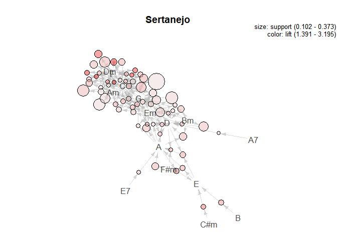

```r
plot(regras.sert,main="Sertanejo",method = "graph")
```

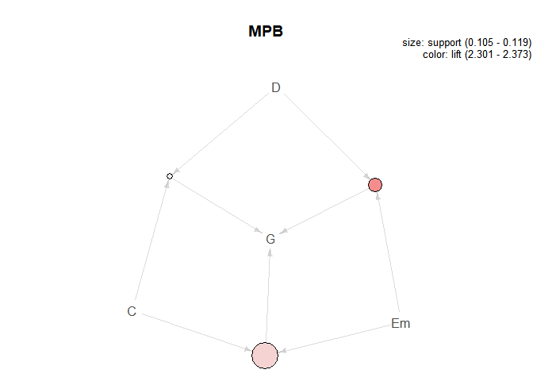

```r
plot(regras.mpb,main="MPB",method="graph")
```

## Conclusão

É possível perceber pelo número de regras e pela “força” delas que realmente parece existir menos diversidade, isto é, mais repetição nos acordes de música sertaneja.

## Utilidade

- **Músicos**: Saber se irá se especializar em harmonia ou técnica caso toque em um cenário sertanejo. Além de estudar mais progressões e frases nos campos harmônicos de C/Am, G/Em, D/Bm e E/Dbm.
- **Pesquisadores**: Iniciar uma discussão sobre os diferentes estilos musicais e suas complexidades.

##Materiais de apoio / Referências [Linguagem de Consulta Xpath](http://leg.ufpr.br/~walmes/ensino/web-scraping/li%C3%A7%C3%B5es/5-xpath-usage/)

CHEW, Elaine; CHILDS, Adrian; CHUAN, Ching-Hua (Ed.). **Mathematics and Computation in Music: Second International Conference, MCM 2009, New Haven, CT, USA, June 19-22, 2009. Proceedings**. Springer Science & Business Media, 2009.

LANTZ, Brett.**Machine learning with R**. Packt Publishing Ltd, 2013.